# Структура научной презентации

Презентация лабораторной работы № 13

Ахмад Мд Шешир.

Российский университет дружбы народов, Москва, Россия

## Докладчик

- Ахмад Мд Шешир
- Cтудент
- Российский университет дружбы народов

[figure not shown]

# Цель работы

Изучить основы программирования в оболочке ОС UNIX/Linux. Научиться писать небольшие командные файлы.

**1**. Написать на языке Си программу, которая вводит число и определяет, является ли оно больше нуля, меньше нуля или равно нулю. Затем программа завершается с помощью функции exit(n), передавая информацию в о коде завершения в оболочку. Командный файл должен вызывать эту программу и, проанализировав с помощью команды “$?”, выдать сообщение о том, какое число было введено.

## 1

Открываю текстовый редактор и создаю новый файл для кода на С

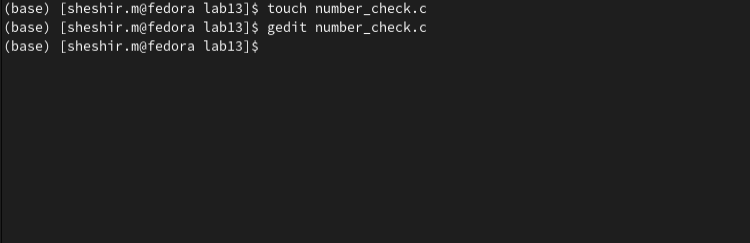

## 2

Программа запрашивает у пользователя ввод числа, определяет является ли оно положительным отрицательным или равным нулю, а затем завершает работу.

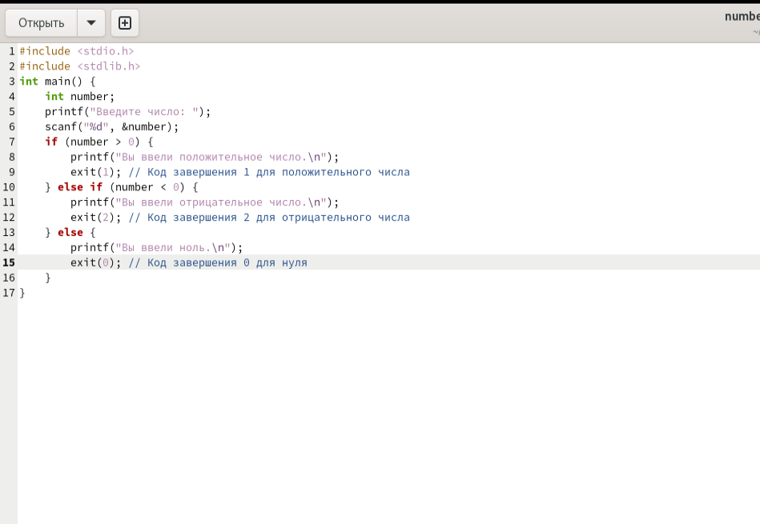

Набераю текст

## 3

Создаю исполняемый файл, выполнив команду в терминале gcc для языка С

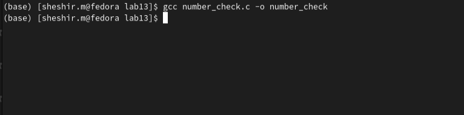

## 4

Создаю новый файл для кода для BASH и набираю программу

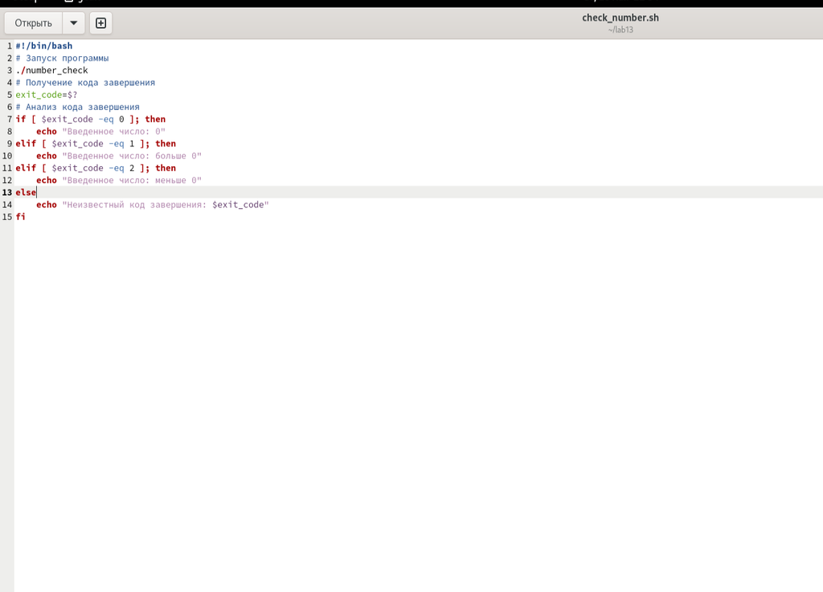

## 5

Делаю файл исполняемым, выполнив команду в терминале chmod

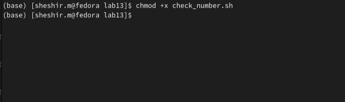

## 6

Запускаю исполняемы файл, и пишу любое число 5, все работает

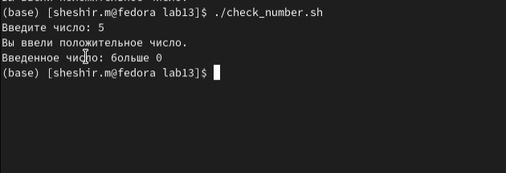

## вывод

В ходе работы я изучил основы программирования в оболочке ОС UNIX/Linux. Научился писать небольшие командные файлы.